# Team Name

1. Jeevan Rai
2. Arman Kamal

```python
!pip install tensorflow==2.16.2
```

```python
!pip install tqdm==4.66.3
```

```python
!pip install numpy==1.23.5
```

```python
!pip install tf-keras==2.16
```

```python
import pandas as pd
import torch
import tensorflow as tf
import numpy as np
import tf_keras
from transformers import BertTokenizer, BertForSequenceClassification, Trainer, TrainingArguments, AutoTokenizer
from torch.utils.data import DataLoader, RandomSampler, SequentialSampler, TensorDataset
from torch.utils.data import random_split
from torch.utils.data import TensorDataset
from torch.optim import Adam
import torch.optim.lr_scheduler as lr_scheduler  # to adjust learning rate dynamically during training
from sklearn.metrics import accuracy_score
from torch import nn
from tqdm.notebook import tqdm, trange
import matplotlib
import matplotlib.pyplot as plt
import time
```

```python
!pip install matplotlib==3.5.0
```

```python
# Check versions
print(torch.__version__)
print(tf.__version__)
print(tf_keras.__version__)
print(np.__version__)
print(matplotlib.__version__)
```

```
2.5.1+cu124
2.16.2
2.16.0
1.23.5
3.5.0
```

# Overview of the dataset

We are using Amazon product reviews dataset.The reviews are labeled with sentiment categories: positive, neutral, or negative. This dataset is commonly used in natural language processing (NLP) tasks involving sentiment analysis.

Link to the dataset: https://github.com/3ashryy2/Amazon-Reviews-Sentiment-Analysis/tree/main

**Classification Task:**

The goal is to perform sentiment analysis on customer reviews, classifying each review into one of three categories positive, neutral, negative.

**Business Case:**

- **Customer Feedback Analysis:** This can be used for insights into product performance, customer satisfaction, or service improvements.
- **Product Improvement:** We can analyze negative reviews which will help to identify potential issues and improve products or services. This could help in preventing churn by proactively addressing negative feedback.
- **Market Sentiment Tracking:** By analyzing positive reviews we can help business with marketing and sales strategies.
- **Presonalized Marketing & Recommendations:** Sentiment analysis helps in customizing marketing messages based on customer feedback. Business can implement strategies like customer referrals, discounts, free returns, etc. for customer retention.

**Multi Task:**

This dataset is not multi-task. It focuses solely on a single task- classifying reviews based on their sentiments (positive, negative or neutral).

**Feature Data**

The primary feature is "cleaned_review", which has been preprocessed which includes removing stopwords, removing non-alphanumeric characters, and changing all the text to lowercase. The dataset also contains features "cleaned_review_length" and "review_score" which are not being used in this report. The target variable is "sentiments" which indicates a sentiment for a review.

The data was collected by Amazon as part of their customer feedback system. These customer reviews were submitted after making purchases by the customers on Amazon website. The data was collected from customers to express their opinions and to help businesses improve products and services based on feedback and also to know about customers preference. The dataset is from Amazon's product review system. While the exact collection date isn't specified, the reviews are continuously collected as part of Amazon's regular operations. The preprocessed dataset "amazon_reviews.csv", used in this report, was collected from the github link provided above.

**Multi-Modal**

No, the data is not multi-modal. It only consists text-based reviews

**Evaluation Criteria**

To evaluate the performance of our sentiment classification model, we will use the following key metrics:

1. **Accuracy:** It measures the proportion of correctly classified reviews out of all reviews. It gives an overall sense of the model’s performance. As we are simply measuring how well a trined model predicts a sentiment for a review, a simple accuracy measure is reliable evaluation metric.
2. **Cross-entropy Loss (Validation Loss & Training Loss)** The training loss indicates how well the model is learning during training. Lower values suggest the model is fitting well to the data. The validation loss helps detect overfitting—if it remains high while training loss decreases, the model may be memorizing rather than generalizing. Cross-entropy loss is well-suited for multi-class classification problems where we are predicting probabilities across multiple categories. It also effectively penalizes incorrect confident predictions.

**Business Case Support:**

A high accuracy ensures the model is correctly identifying positive, neutral, and negative sentiments which will help businesses interpret overall customer satisfaction.

A lower validation loss ensures that the model generalizes well to unseen data, making sentiment predictions reliable for real-world customer reviews.

# Base/Foundational Model

## Load the dataset

```python
# github path to "amazon_reviews.csv" file
file_path = "https://raw.githubusercontent.com/yamphurai/Fairness_and_Ethical_considerations/refs/heads/main/amazon_reviews.csv"
```

```python
# Read the dataset
dataset = pd.read_csv(file_path)
```

```python
dataset.head()
```

|  | sentiments | cleaned_review | cleaned_review_length | review_score |
| --- | --- | --- | --- | --- |
| 0 | positive | i wish would have gotten one earlier love it a... | 19 | 5.0 |
| 1 | neutral | i ve learned this lesson again open the packag... | 88 | 1.0 |
| 2 | neutral | it is so slow and lags find better option | 9 | 2.0 |
| 3 | neutral | roller ball stopped working within months of m... | 12 | 1.0 |
| 4 | neutral | i like the color and size but it few days out ... | 21 | 1.0 |

```python
# Basic statistics
dataset.describe(include="all")
```

|  | sentiments | cleaned_review | cleaned_review_length | review_score |
| --- | --- | --- | --- | --- |
| count | 17340 | 17321 | 17340.000000 | 17340.000000 |
| unique | 3 | 13100 | NaN | NaN |
| top | positive | love it | NaN | NaN |
| freq | 9503 | 71 | NaN | NaN |
| mean | NaN | NaN | 30.300461 | 3.649077 |
| std | NaN | NaN | 35.836540 | 1.673500 |
| min | NaN | NaN | 0.000000 | 1.000000 |
| 25% | NaN | NaN | 9.000000 | 2.000000 |
| 50% | NaN | NaN | 20.000000 | 5.000000 |
| 75% | NaN | NaN | 38.000000 | 5.000000 |
| max | NaN | NaN | 571.000000 | 5.000000 |

```python
# let's take a loot at all sentiments
dataset["sentiments"].unique()
```

```
array(['positive', 'neutral', 'negative'], dtype=object)
```

```python
# Checking for null values in each column
print(dataset["sentiments"].isna().sum())
print(dataset["cleaned_review"].isna().sum())
print(dataset["cleaned_review_length"].isna().sum())
print(dataset["review_score"].isna().sum())
```

```
0
19
0
0
```

There are three sentiments (labels) assigned as discussed previously. There are 19 rows that don't have any reviews under "cleaned_review" column.

```python
# let's evaluate the rows with null values
print(dataset[dataset["cleaned_review"].isna()])
```

```
      sentiments cleaned_review  cleaned_review_length  review_score
2085     neutral            NaN                      0           5.0
2894     neutral            NaN                      0           5.0
4333     neutral            NaN                      0           5.0
6043     neutral            NaN                      0           5.0
6841     neutral            NaN                      0           4.0
9526     neutral            NaN                      0           4.0
10063    neutral            NaN                      0           3.0
11388    neutral            NaN                      0           5.0
12912    neutral            NaN                      0           4.0
14435    neutral            NaN                      0           5.0
15481    neutral            NaN                      0           5.0
15557    neutral            NaN                      0           5.0
16222    neutral            NaN                      0           4.0
16495    neutral            NaN                      0           5.0
16502    neutral            NaN                      0           5.0
16529    neutral            NaN                      0           5.0
16802    neutral            NaN                      0           5.0
16911    neutral            NaN                      0           5.0
17281    neutral            NaN                      0           5.0
```

There are only 19 null values which is only 0.1% of the total reviews. Also, we can't replace them with any other statistical values since these are to be filled with reviews which is not possible. So we will remove them.

```python
# drop null values
dataset = dataset.dropna(subset=["cleaned_review"])
```

```python
# Basic statistics
dataset.describe(include="all")
```

|  | sentiments | cleaned_review | cleaned_review_length | review_score |
| --- | --- | --- | --- | --- |
| count | 17321 | 17321 | 17321.000000 | 17321.000000 |
| unique | 3 | 13100 | NaN | NaN |
| top | positive | love it | NaN | NaN |
| freq | 9503 | 71 | NaN | NaN |
| mean | NaN | NaN | 30.333699 | 3.647942 |
| std | NaN | NaN | 35.842128 | 1.673961 |
| min | NaN | NaN | 1.000000 | 1.000000 |
| 25% | NaN | NaN | 9.000000 | 2.000000 |
| 50% | NaN | NaN | 20.000000 | 5.000000 |
| 75% | NaN | NaN | 38.000000 | 5.000000 |
| max | NaN | NaN | 571.000000 | 5.000000 |

No null values left in the dataset. We ended having 17,321 samples in our dataset.

```python
dataset_final = dataset[["sentiments", "cleaned_review"]]
```

```python
# final dataset
dataset_final.head()
```

|  | sentiments | cleaned_review |
| --- | --- | --- |
| 0 | positive | i wish would have gotten one earlier love it a... |
| 1 | neutral | i ve learned this lesson again open the packag... |
| 2 | neutral | it is so slow and lags find better option |
| 3 | neutral | roller ball stopped working within months of m... |
| 4 | neutral | i like the color and size but it few days out ... |

Here is our final dataset "dataset_final" that contains feature "cleaned_review" and target column "sentiments".

# Foundational Model for Transfer Learning: BERT-base-uncased

For classification task, we are using BERT-base-uncased, a pretrained Transformer-based language model developed by Google.

It’s a bidirectional transformer pretrained using a combination of masked language modeling objective and next sentence prediction on a large corpus comprising the Toronto Book Corpus and Wikipedia.

**Masked Language Modeling(MLM)**: Some words in a sentence are randomly masked, and the model learns to predict them based on surrounding context. This enables deep bidirectional understanding of language.

**Next Sentence Prediction (NSP)**: Given two sentences, the model predicts whether the second sentence follows the first. This helps in tasks that require understanding sentence relationships, such as question-answering or dialogue generation.

The new task of classification of reviews fall in same domain as BERT's pretraining. BERT was originally trained on general textual data, and sentiment classification is a text-based task. The new task, which is sentiment classification of Amazon product reviews, is also a text-based task. Since BERT already understands language structure, word relationships, and context, we can adapt it to sentiment classification with a smaller labeled dataset.

## Load BERT model and tokenizer

We will load the pretrained BERT uncased model. We want to perform classification, so we will need to get BertForSequenceClassifiction as it includes a fully connected classification layer on top of the BERT model

```python
# Load the BERT model
model_base = BertForSequenceClassification.from_pretrained('bert-base-uncased',
                                                      num_labels=3,
                                                      output_hidden_states=False
                                                     )
```

```
Some weights of BertForSequenceClassification were not initialized from the model checkpoint at bert-base-uncased and are newly initialized: ['classifier.bias', 'classifier.weight']
You should probably TRAIN this model on a down-stream task to be able to use it for predictions and inference.
```

```python
# Load the BERT tokenizer
tokenizer = BertTokenizer.from_pretrained('bert-base-uncased')
```

```python
# Let's evaluate the base model architecture
model_base
```

```
BertForSequenceClassification(
  (bert): BertModel(
    (embeddings): BertEmbeddings(
      (word_embeddings): Embedding(30522, 768, padding_idx=0)
      (position_embeddings): Embedding(512, 768)
      (token_type_embeddings): Embedding(2, 768)
      (LayerNorm): LayerNorm((768,), eps=1e-12, elementwise_affine=True)
      (dropout): Dropout(p=0.1, inplace=False)
    )
    (encoder): BertEncoder(
      (layer): ModuleList(
        (0-11): 12 x BertLayer(
          (attention): BertAttention(
            (self): BertSdpaSelfAttention(
              (query): Linear(in_features=768, out_features=768, bias=True)
              (key): Linear(in_features=768, out_features=768, bias=True)
              (value): Linear(in_features=768, out_features=768, bias=True)
              (dropout): Dropout(p=0.1, inplace=False)
            )
            (output): BertSelfOutput(
              (dense): Linear(in_features=768, out_features=768, bias=True)
              (LayerNorm): LayerNorm((768,), eps=1e-12, elementwise_affine=True)
              (dropout): Dropout(p=0.1, inplace=False)
            )
          )
          (intermediate): BertIntermediate(
            (dense): Linear(in_features=768, out_features=3072, bias=True)
            (intermediate_act_fn): GELUActivation()
          )
          (output): BertOutput(
            (dense): Linear(in_features=3072, out_features=768, bias=True)
            (LayerNorm): LayerNorm((768,), eps=1e-12, elementwise_affine=True)
            (dropout): Dropout(p=0.1, inplace=False)
          )
        )
      )
    )
    (pooler): BertPooler(
      (dense): Linear(in_features=768, out_features=768, bias=True)
      (activation): Tanh()
    )
  )
  (dropout): Dropout(p=0.1, inplace=False)
  (classifier): Linear(in_features=768, out_features=3, bias=True)
)
```

**Base model architecture:**

```python
# place the based model to GPU if available
device = torch.device("cuda" if torch.cuda.is_available() else "cpu")
model_base.to(device)
```

```
BertForSequenceClassification(
  (bert): BertModel(
    (embeddings): BertEmbeddings(
      (word_embeddings): Embedding(30522, 768, padding_idx=0)
      (position_embeddings): Embedding(512, 768)
      (token_type_embeddings): Embedding(2, 768)
      (LayerNorm): LayerNorm((768,), eps=1e-12, elementwise_affine=True)
      (dropout): Dropout(p=0.1, inplace=False)
    )
    (encoder): BertEncoder(
      (layer): ModuleList(
        (0-11): 12 x BertLayer(
          (attention): BertAttention(
            (self): BertSdpaSelfAttention(
              (query): Linear(in_features=768, out_features=768, bias=True)
              (key): Linear(in_features=768, out_features=768, bias=True)
              (value): Linear(in_features=768, out_features=768, bias=True)
              (dropout): Dropout(p=0.1, inplace=False)
            )
            (output): BertSelfOutput(
              (dense): Linear(in_features=768, out_features=768, bias=True)
              (LayerNorm): LayerNorm((768,), eps=1e-12, elementwise_affine=True)
              (dropout): Dropout(p=0.1, inplace=False)
            )
          )
          (intermediate): BertIntermediate(
            (dense): Linear(in_features=768, out_features=3072, bias=True)
            (intermediate_act_fn): GELUActivation()
          )
          (output): BertOutput(
            (dense): Linear(in_features=3072, out_features=768, bias=True)
            (LayerNorm): LayerNorm((768,), eps=1e-12, elementwise_affine=True)
            (dropout): Dropout(p=0.1, inplace=False)
          )
        )
      )
    )
    (pooler): BertPooler(
      (dense): Linear(in_features=768, out_features=768, bias=True)
      (activation): Tanh()
    )
  )
  (dropout): Dropout(p=0.1, inplace=False)
  (classifier): Linear(in_features=768, out_features=3, bias=True)
)
```

## Preprocess the final dataset

```python
# Let's look at the max length tokens of the review in the dataset

# Tokenizing each sample and counting the number of tokens
token_counts = dataset["cleaned_review"].apply(lambda x: len(tokenizer.encode(x, add_special_tokens=True)))

# Find the maximum token count in the dataset
max_token_count = token_counts.max()
print("Maximum token count in the dataset:", max_token_count)
```

```
Token indices sequence length is longer than the specified maximum sequence length for this model (545 > 512). Running this sequence through the model will result in indexing errors
```

```
Maximum token count in the dataset: 598
```

Since there are some reviews that have more than 512 tokens, we will need to truncate them to 512 tokens to be used for BERT model.

```python
max_tokens = 512

# list to store each sample as a dictionary that contains tokenized review and corresponding label
encoded_dataset = []

# to count samples processed
samples_processed = 0

# Map the text labels to integers
label_map = {"negative":0, "neutral":1, "positive":2}


# iterate through each sample in the dataset_final
for text, label in tqdm(zip(dataset_final['cleaned_review'], dataset_final['sentiments']), desc="Encoding", total=len(dataset_final['sentiments'])):

    # Tokenize the text with truncation and padding. Returned as PyTorch tensors
    encoded_example = tokenizer(text, return_tensors='pt',
                                truncation=True,
                                padding='max_length',
                                max_length=max_tokens)

    # Convert the string labels to integer labels as mapped above
    encoded_example['label_id'] = label_map.get(label)

    # Check if the tokenized sequence length is correct
    assert len(encoded_example.input_ids[0]) == max_tokens

    # Add the encoded example to the dataset_final
    encoded_dataset.append(encoded_example)
```

```python
# Let's evaluate sample at index 1 to see the encoded sample
encoded_dataset[1]
```

```
{'input_ids': tensor([[  101,  1045,  2310,  4342,  2023, 10800,  2153,  2330,  1996,  7427,
          1998,  2224,  1996,  4031,  2157,  2185,  3641,  2023,  8000,  1999,
          2257,  2004,  2026,  3604,  8000,  1998,  2074,  8966,  2009,  2185,
          1999,  2026,  4524,  2085,  2310,  2042,  5873,  2155,  1999,  1996,
          1052,  2078,  2860,  2144,  3054,  2244,  1996,  8000,  2165,  3715,
          1998,  2499,  2986,  2005,  3232,  1997,  3134,  2044, 28667,  8167,
          5999,  1996,  8000,  2009,  2499,  2005,  2154,  2030,  2048,  1998,
          2059,  7024,  2000,  3853,  1996,  9380,  2422,  2097,  5956,  2320,
          2043,  2357,  2006,  2059,  2498,  1997,  2607,  1996,  2709,  3332,
          2003,  2092,  2627,   102,     0,     0,     0,     0,     0,     0,
             0,     0,     0,     0,     0,     0,     0,     0,     0,     0,
             0,     0,     0,     0,     0,     0,     0,     0,     0,     0,
             0,     0,     0,     0,     0,     0,     0,     0,     0,     0,
             0,     0,     0,     0,     0,     0,     0,     0,     0,     0,
             0,     0,     0,     0,     0,     0,     0,     0,     0,     0,
```

[output cut: 79 more lines]

We can see the encoded dictionary with keys input_ids, token_type_ids, attention_maks, and label_id with their tensors as their values. All of them have been padded to 512 tokens.

Now we will setup tracking for training and validation loss. We will freeze all the layers of BERT first. Unfreeze the last pooling layer of BERT and its classifier layer. Then we will add them to be passed to the optimzer before being trained.

```python
# setup tracking.
history_base = {}  # empty dict to store training history of the base model
history_base['val_loss'] = []  # stores validation loss values
history_base['train_loss'] = []  # stores training loss values

epochs = 3

# Go thru all parameters of the model and freeze entire model initially.
for param in model_base.parameters():
    param.requires_grad = False

# only train the parameters for pooler layer of BERT (final layer before our classifier layer)
for param in model_base.bert.pooler.parameters():
    param.requires_grad = True

# only train the classifier layer that we added to BERT model
for param in model_base.classifier.parameters():
    param.requires_grad = True

# now add the lists of the parameters from pooler layer and classifier layer to pass them through optimizer
train_params = list(model_base.bert.pooler.parameters()) + list(model_base.classifier.parameters())

# we can now tell the optimizer to only optimize these parameters in the model
optimizer = Adam(train_params)
```

## Training and Evaluation datasets using Random Split

Create a tensor dataset from our dataset_final that takes all of the tensors from input text and labels, and combine them into a single dataset object. This ensures that all the required inputs for our BERT model are packaged together and we can do batch processing.

We are using a simple random split of 80-20 (80% as training) for splitting the dataset into training and testing datasets. 17,321 samples is not massive compared to datasets BERT was originally trained on. A simple train-test split can be effective since fine-tuning BERT does not require extremely large datasets. The dataset could be slightly imblanaced but we can still use this normal split method to keep it simple and less computational.

```python
Batch_size = 16
total_reviews = 17321   #total number of reviews
train_size = int(0.8*total_reviews)   #set 80% as training data
eval_size = total_reviews - train_size   #set 20% as evaluation data


# Create the TensorDataset by extracting values from the existing dataset
input_ids = torch.stack([sample['input_ids'].squeeze(0) for sample in encoded_dataset], dim=0)
attention_mask = torch.stack([sample['attention_mask'].squeeze(0) for sample in encoded_dataset], dim=0)
token_type_ids = torch.stack([sample['token_type_ids'] for sample in encoded_dataset], dim=0)
label_ids = torch.tensor([sample['label_id'] for sample in encoded_dataset], dtype=torch.long)

# Create the TensorDataset
all_data_tensors = TensorDataset(input_ids, attention_mask, token_type_ids, label_ids)

# randomly split that dataset into trainig and evaluation datasets
train_data, eval_data = random_split(all_data_tensors, [train_size, eval_size])

# take random samples from the training data as training samples)
train_sampler = RandomSampler(train_data)
train_dataloader = DataLoader(train_data, sampler=train_sampler, batch_size=Batch_size)  #load the samples in batches

# do the same for the evaluation dataset (no need to random pick)
eval_sampler = SequentialSampler(eval_data)
eval_dataloader = DataLoader(eval_data, sampler=eval_sampler, batch_size=Batch_size)

print(f"Created two datasets training/eval. Training samples: {train_size}, Evaluation: {eval_size}")

# free up some memory, already saved in the new dataset "all_data_tensors"
del encoded_dataset
```

```
Created two datasets training/eval. Training samples: 13856, Evaluation: 3465
```

When we tokenized the texts and computed tensors, there will be one extra batch dimension in the input_ids, attention_mask. The BertForSequenceClassification expects only 2D tensor for these parameters i.e. [batch_size, seq_length]. So we performed "squeeze" above. So let's check their shapes before proceeding.

```python
print(input_ids.shape)  # Should be [16, 512]
print(attention_mask.shape)  # Should be [16, 512]
print(label_ids.shape)  # Should be [16]
```

```
torch.Size([17321, 512])
torch.Size([17321, 512])
torch.Size([17321])
```

Since we have not performed batch processing yet, there are 17321 samples in the dataset, and they all have 512 tensors. We are good to proceed.

```python
# Iterate over the train_dataloader and print the first batch
for batch in train_dataloader:
  input_ids, attention_mask, token_type_ids, labels = batch  # Unpack the batch
  print(input_ids)
  print(attention_mask)
  print(token_type_ids)
  print(labels)
  break  # Only print the first batch, remove break to print all batches
```

```
tensor([[  101,  2005,  2151,  ...,     0,     0,     0],
        [  101,  9233, 11754,  ...,     0,     0,     0],
        [  101,  2828, 19400,  ...,     0,     0,     0],
        ...,
        [  101,  3866,  2023,  ...,     0,     0,     0],
        [  101,  2307,  3737,  ...,     0,     0,     0],
        [  101,  2200,  2204,  ...,     0,     0,     0]])
tensor([[1, 1, 1,  ..., 0, 0, 0],
        [1, 1, 1,  ..., 0, 0, 0],
        [1, 1, 1,  ..., 0, 0, 0],
        ...,
        [1, 1, 1,  ..., 0, 0, 0],
        [1, 1, 1,  ..., 0, 0, 0],
        [1, 1, 1,  ..., 0, 0, 0]])
tensor([[[0, 0, 0,  ..., 0, 0, 0]],

        [[0, 0, 0,  ..., 0, 0, 0]],

        [[0, 0, 0,  ..., 0, 0, 0]],

        ...,

        [[0, 0, 0,  ..., 0, 0, 0]],

        [[0, 0, 0,  ..., 0, 0, 0]],

        [[0, 0, 0,  ..., 0, 0, 0]]])
tensor([2, 1, 1, 2, 0, 2, 1, 1, 2, 2, 1, 2, 2, 2, 1, 2])
```

Checking the first batch from the training dataset, we can see that we have all the tensors as values for corresponding keys in the dictionary. There are 16 samples in the batch.

```python
# Iterate over the eva_dataloader and print the first batch
for batch in eval_dataloader:
  input_ids, attention_mask, token_type_ids, labels = batch  # Unpack the batch
  print(input_ids)
  print(attention_mask)
  print(token_type_ids)
  print(labels)
  break  # Only print the first batch, remove break to print all batches
```

```
tensor([[  101,  2009,  2499,  ...,     0,     0,     0],
        [  101,  4149,  2023,  ...,     0,     0,     0],
        [  101,  3030,  2551,  ...,     0,     0,     0],
        ...,
        [  101, 12476,  4641,  ...,     0,     0,     0],
        [  101,  2293,  1996,  ...,     0,     0,     0],
        [  101,  2054,  2134,  ...,     0,     0,     0]])
tensor([[1, 1, 1,  ..., 0, 0, 0],
        [1, 1, 1,  ..., 0, 0, 0],
        [1, 1, 1,  ..., 0, 0, 0],
        ...,
        [1, 1, 1,  ..., 0, 0, 0],
        [1, 1, 1,  ..., 0, 0, 0],
        [1, 1, 1,  ..., 0, 0, 0]])
tensor([[[0, 0, 0,  ..., 0, 0, 0]],

        [[0, 0, 0,  ..., 0, 0, 0]],

        [[0, 0, 0,  ..., 0, 0, 0]],

        ...,

        [[0, 0, 0,  ..., 0, 0, 0]],

        [[0, 0, 0,  ..., 0, 0, 0]],

        [[0, 0, 0,  ..., 0, 0, 0]]])
tensor([0, 2, 1, 1, 2, 2, 2, 0, 2, 2, 2, 0, 2, 2, 2, 2])
```

Same as above for evaluation dataset

### Train baseline BERT model

Next, we will train our model for certain number of epochs. While training, we will track the training loss. After each epoch, we will evaluate the model's performance on the validation set. This validation loss will also be tracked. We will save the loss values for training and validation for future analysis.

```python
# setting up a progress bar for epochs
with trange(epochs, desc="Epoch") as pbar:

    for epoch in pbar:
        model_base.train()  # put the model in training mode
        total_loss  = 0.0  # track the training loss

        # iterate over training data in batchs using train_dataloader.
        for batch in tqdm(train_dataloader, desc=f"Training {epoch}", total=int(train_size/Batch_size)+1, leave=False):

            # send batch (tuple of below input parameters & labels) to GPU and separate for the model
            batch = tuple(s.to(device) for s in batch)
            input_ids, input_mask, input_types, labels = batch  # unpack those parameters of the tuple

            # pass these parameters thru model to perform forward pass. This will compute model's output (includes training loss)
            output = model_base(input_ids=input_ids, attention_mask=input_mask, labels=labels)

            # back propagation
            output.loss.backward() # computes gradients by backpropagation using the loss
            optimizer.step() # use gradients in optimizer to update model's parameters
            optimizer.zero_grad() # clear out gradients of optimized tensors to avoid accumulation of gradients between different batches

            # keep track of total train loss. Need to multiply loss per sample by batch size for total loss
            total_loss += output.loss.item() * Batch_size

        # calcualte the avg. training loss and add it to the train_loss
        total_loss  = total_loss / train_size
        history_base['train_loss'].append(total_loss)

        # print the train loss in the progress bar for the epochs
        pbar.set_postfix(loss=f"{total_loss:.2f}")

        # at end of epoch, report the evaluation
        model_base.eval()  # Set model to evaluation mode (droput layers and other training specific operations are turned off)
        total_loss  = 0.0  #rest the total loss to 0 to track the validation loss

        # turn of gradient calculation as we're only evaluating the model
        with torch.no_grad():

            # evaluation in batches (same as above)
            for batch in tqdm(eval_dataloader, desc=f"Evaluating {epoch}", total=int(eval_size/Batch_size)+1, leave=False):
                batch = tuple(s.to(device) for s in batch) # send to GPU
                input_ids, input_mask, input_types, labels = batch
                output = model_base(input_ids, input_types, input_mask, labels=labels)
                total_loss += output.loss.item() * Batch_size

            total_loss  = total_loss / eval_size
            history_base['val_loss'].append(total_loss)

        # print the eval loss in the progress bar for the epochs
        pbar.set_postfix(loss=f"{total_loss:.2f}")
```

```python
# Check the losses for each batch at each epoch
print(history_base)
```

```
{'val_loss': [4.477474971182247, 3.9596863343430115, 4.339250472648147], 'train_loss': [0.5246345545175995, 0.5263376238715015, 0.5178466529841373]}
```

## Training and Evaluation datasets using Stratified CV

```python
dataset_final["sentiments"].value_counts()
```

```
positive    9503
neutral     6284
negative    1534
Name: sentiments, dtype: int64
```

So there are 54%, 36%, and 10% (roughly) reviews labelled as positive, neutral, and negative respectively. So there is significant data imbalance.

```python
from sklearn.model_selection import StratifiedKFold
from torch.utils.data import DataLoader, Subset
```

```python
n_splits = 3  # Number of folds
scv = StratifiedKFold(n_splits=n_splits, shuffle=True, random_state=42)

Batch_size = 16
epochs = 3  # Number of training epochs
optimizer = Adam(train_params)

# Extract input tensors and labels from dataset
input_ids = torch.stack([sample['input_ids'].squeeze(0) for sample in encoded_dataset], dim=0)
attention_mask = torch.stack([sample['attention_mask'].squeeze(0) for sample in encoded_dataset], dim=0)
token_type_ids = torch.stack([sample['token_type_ids'] for sample in encoded_dataset], dim=0)
label_ids = torch.tensor([sample['label_id'] for sample in encoded_dataset], dtype=torch.long)

# Convert labels to NumPy array for StratifiedKFold (use CPU)
labels_np = label_ids.cpu().numpy()

# Create the full dataset
all_data_tensors = TensorDataset(input_ids, attention_mask, token_type_ids, label_ids)

# track the training and validation losses
history_scv = {'train_loss': [], 'val_loss': []}
```

### GPU check

```python
!nvidia-smi
```

```
Sun Mar  2 22:26:48 2025
+-----------------------------------------------------------------------------------------+
| NVIDIA-SMI 550.127.08             Driver Version: 550.127.08     CUDA Version: 12.4     |
|-----------------------------------------+------------------------+----------------------+
| GPU  Name                 Persistence-M | Bus-Id          Disp.A | Volatile Uncorr. ECC |
| Fan  Temp   Perf          Pwr:Usage/Cap |           Memory-Usage | GPU-Util  Compute M. |
|                                         |                        |               MIG M. |
|=========================================+========================+======================|
|   0  NVIDIA A100-SXM4-80GB          On  |   00000000:BD:00.0 Off |                    0 |
| N/A   33C    P0             66W /  400W |       1MiB /  81920MiB |      0%      Default |
|                                         |                        |             Disabled |
+-----------------------------------------+------------------------+----------------------+

+-----------------------------------------------------------------------------------------+
| Processes:                                                                              |
|  GPU   GI   CI        PID   Type   Process name                              GPU Memory |
|        ID   ID                                                               Usage      |
|=========================================================================================|
|  No running processes found                                                             |
+-----------------------------------------------------------------------------------------+
```

```python
if torch.cuda.is_available():
    print(f"Available GPU: {torch.cuda.get_device_name(0)}")
    print(f"CUDA Device Count: {torch.cuda.device_count()}")
    print(f"Current GPU Index: {torch.cuda.current_device()}")
```

```
Available GPU: NVIDIA A100-SXM4-80GB
CUDA Device Count: 1
Current GPU Index: 0
```

### Train the model

```python
# Store training times
Base_model_running_time = []

# Perform Stratified K-Fold Cross-Validation
for fold, (train_idx, eval_idx) in enumerate(scv.split(input_ids, labels_np)):

    print(f"\n--- Fold {fold + 1}/{n_splits} ---")

    # Subset dataset using train and eval indices
    train_data = Subset(all_data_tensors, train_idx)
    eval_data = Subset(all_data_tensors, eval_idx)

    # Create DataLoaders
    train_dataloader = DataLoader(train_data, sampler=RandomSampler(train_data), batch_size=Batch_size)
    eval_dataloader = DataLoader(eval_data, sampler=SequentialSampler(eval_data), batch_size=Batch_size)

    # Reinitialize model for each fold
    model_base.to(device)

    # Start timing
    start_time = time.time()

    with trange(epochs, desc=f"Epoch (Fold {fold + 1})") as pbar:
        for epoch in pbar:
            model_base.train()
            total_loss = 0.0

            # iterate over training data in batchs using train_dataloader.
            for batch in tqdm(train_dataloader, desc=f"Training {epoch}", total=len(train_dataloader), leave=False):

                batch = tuple(s.to(device) for s in batch)
                input_ids, input_mask, input_types, labels = batch

                output = model_base(input_ids=input_ids, attention_mask=input_mask, labels=labels)

                # Backpropagation
                output.loss.backward()
                optimizer.step()
                optimizer.zero_grad()

                total_loss += output.loss.item() * Batch_size

            total_loss = total_loss / len(train_dataloader.dataset)
            history_scv['train_loss'].append(total_loss)
            pbar.set_postfix(loss=f"{total_loss:.2f}")

            # Evaluation
            model_base.eval()
            total_loss = 0.0

            with torch.no_grad():
                for batch in tqdm(eval_dataloader, desc=f"Evaluating {epoch}", total=len(eval_dataloader), leave=False):
                    batch = tuple(s.to(device) for s in batch)
                    input_ids, input_mask, input_types, labels = batch

                    output = model_base(input_ids, input_types, input_mask, labels=labels)
                    total_loss += output.loss.item() * Batch_size

            total_loss = total_loss / len(eval_dataloader.dataset)
            history_scv['val_loss'].append(total_loss)
            pbar.set_postfix(val_loss=f"{total_loss:.2f}")

    # End timing
    end_time = time.time()
    fold_time_base = end_time - start_time
    Base_model_running_time.append(fold_time_base)
    print(f"Training time for Fold {fold + 1}: {fold_time_base:.2f} seconds")

print("\nCross-validation complete!")
print("Base model runing times (seconds):", Base_model_running_time)
```

```
--- Fold 1/3 ---
```

```
Training time for Fold 1: 320.48 seconds

--- Fold 2/3 ---
```

```
Training time for Fold 2: 320.93 seconds

--- Fold 3/3 ---
```

```
Training time for Fold 3: 321.09 seconds

Cross-validation complete!
Base model runing times (seconds): [320.4794239997864, 320.9306137561798, 321.0920555591583]
```

```python
Base_model_running_time
```

```
[320.4794239997864, 320.9306137561798, 321.0920555591583]
```

```python
# Evaluate the losses
print(history_scv)
```

```
{'train_loss': [0.6308016816888566, 0.5666386944045749, 0.5653283992061019, 0.5669913397647194, 0.5515140639018773, 0.5397448867825272, 0.5521809204788327, 0.5437873039623012, 0.5387899148286648], 'val_loss': [1.7058421509217176, 2.1750976141654457, 2.533772724906094, 4.057085842585787, 3.6582723768…
```

Looking at the loss values for each fold and each epoch, we can see that the model has the best training loss at the third fold since it starts from 0.55 and goes to 0.53 after third epoch. The loss values for the other folds start from a little higher value. The loss values improves slightly after first epoch but that could be overfitting as the validation score does not improve in the same proportional in latter epochs.

However, the model has the best validation loss value at first fold since it starts from 1.70 which is smaller than the loss values at first epoch for other two folds. Although, the loss starts to get slightly worse after first epoch, it is still the best performing fold for the model as it starts with very low loss value compared to other folds.

The running time for the base model for fold 1 is 320.48 seconds.

So now when we compare the best validation loss of this model to the one that was trained using normal random split, we see that this method shows better performance at generalizing. Teh validiation score is 1.70 for this model while it's 4.47 for the previous model. But for the training loss, it starts with training loss value of 0.55 while it starts with 0.52 for previous model. This difference is not that signficant. So based on this assessment, we can say that using stratified cross validation is a better approach for splitting the dataset into training and testing.

### Model predictions and accuracy

Now, let's grab the predicted and true labels to be used for further analysis.

```python
print(f"Shape of input_ids: {input_ids.shape}")  # Should be (17321, something)
print(f"Shape of labels_np: {labels_np.shape}")  # Should be (17321,)

print(type(input_ids))
print(type(labels_np))
```

```
Shape of input_ids: torch.Size([9, 512])
Shape of labels_np: (17321,)
<class 'torch.Tensor'>
<class 'numpy.ndarray'>
```

To use stratified CV, both input_ids and labels_np need to be numpy arrays of same lengths. Since the input_ids is a torch tensor of different length, we will need to convert it into numpy array.

```python
input_ids_new = torch.cat([sample['input_ids'] for sample in encoded_dataset], dim=0)
```

```python
# re-create the input_ids correctly (different from previous) to numpy arrays
input_ids_np = input_ids_new.cpu().numpy()  # Move to CPU and convert to NumPy
```

```python
print(type(input_ids_np))
print(f"Shape of input_ids_np: {input_ids_np.shape}")  # Should be (17321, something)
```

```
<class 'numpy.ndarray'>
Shape of input_ids_np: (17321, 512)
```

Since it's a numpy array of same lenght as the labels_np, we can proceed.

```python
all_preds_base = []   # Stores predicted labels for each fold
all_labels_base = []  # Stores true labels for each fold

# Extract labels for stratification because it requires labels for equal proportion of classes cross folds
labels_array = np.array([tensor[-1].cpu().numpy() for tensor in all_data_tensors]) # Assuming last tensor is labels

# Cross-validation loop
for fold, (train_idx, eval_idx) in enumerate(scv.split(np.zeros(len(labels_array)), labels_array)):

    print(f"Evaluating fold {fold + 1}/{n_splits}...")

    model_base.eval()  # Set model to evaluation mode

    # Create evaluation dataset and dataloader for this fold
    eval_data_scv = torch.utils.data.Subset(all_data_tensors, eval_idx)
    eval_sampler_scv = SequentialSampler(eval_data_scv)
    eval_dataloader_scv = DataLoader(eval_data_scv, sampler=eval_sampler_scv, batch_size=Batch_size)

    fold_preds_base = []  # Store predictions for this fold
    fold_labels_base = []  # Store true labels for this fold

    # Run evaluation without tracking gradients
    with torch.no_grad():
        for batch in tqdm(eval_dataloader_scv, desc=f"Evaluating Fold {fold + 1}", total=int(len(eval_data_scv)/Batch_size)+1):

            batch = tuple(s.to(device) for s in batch)  # Move batch to GPU/CPU
            input_ids, input_mask, input_types, labels = batch

            # Forward pass (ensure correct argument names)
            output = model_base(input_ids=input_ids, attention_mask=input_mask, labels=None)

            # Store predictions and labels
            fold_preds_base.append(output.logits.detach().cpu().numpy())
            fold_labels_base.append(labels.cpu().numpy())

    # Store predictions per fold
    all_preds_base.append(np.concatenate(fold_preds_base, axis=0))  # Convert list of batches to array
    all_labels_base.append(np.concatenate(fold_labels_base, axis=0))  # Convert list of labels to array
```

```
Evaluating fold 1/3...
```

```
Evaluating fold 2/3...
```

```
Evaluating fold 3/3...
```

Previously we found that first fold provided us the best performance for our base model. So we will use that fold to get the predicted and actual lables of the reviews and compute accuracy.

```
Accuracy for Best Fold 1: 0.7943
```

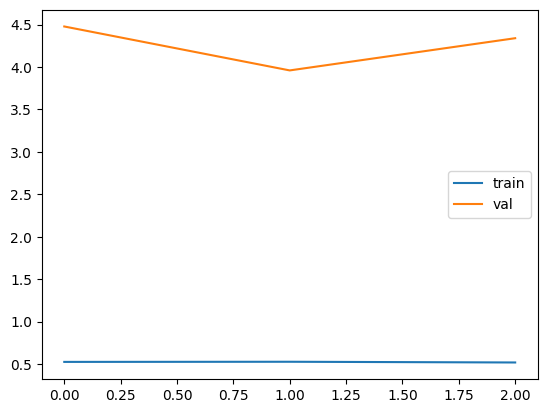

```python
# Select the best fold (i.e. first fold)
best_fold_idx_base = 0

# Get predicted logits and true labels from the best fold
preds_best_fold_base = all_preds_base[best_fold_idx_base]  # Predicted logits
labels_best_fold_base = all_labels_base[best_fold_idx_base]  # True labels


# Convert logits to class predictions
pred_labels_best_fold = np.argmax(preds_best_fold_base, axis=1)

# Compute accuracy
accuracy_best_fold = accuracy_score(labels_best_fold_base, pred_labels_best_fold)

print(f"Accuracy for Best Fold {best_fold_idx_base + 1}: {accuracy_best_fold:.4f}")

# take the loss values from the best performing fold (fold 1)
history_scv['val_loss'] = history_scv['val_loss'][:3]
history_scv['train_loss'] = history_scv['train_loss'][:3]

# Plot the loss values
plt.plot(history_base['train_loss'], label='train')
plt.plot(history_base['val_loss'], label='val')
plt.legend()
plt.show()
```

### Save the trained base model and download for future use

```python
# Save the trained model & tokenizer (for google colab)
model_base.save_pretrained("bert_model_base")
tokenizer.save_pretrained('/content/bert_model_base')
```

```python
!zip -r bert_model_base.zip bert_model_base
```

```python
from google.colab import files
files.download("bert_model_base.zip")
```

```python
# Define save directory (for Jupyter notebook only)
save_directory = "bert_model_base"

# Save the model
model_base.save_pretrained(save_directory)

# Save the tokenizer
tokenizer.save_pretrained(save_directory)

print(f"Base Model and tokenizer saved to: {save_directory}")
```

```
Base Model and tokenizer saved to: bert_model_base
```

# Transfer Learning

## Load up the pre-trained BERT base model

```python
import zipfile
```

```python
# Load the model (For google colab only)

# Path to the .zip file
zip_file_path = '/content/bert_model_base.zip'

# Directory where the model will be extracted (need to make sure that all the necesary files of saved model are NOT be in nested folder)
extract_path = '/content/bert_model_base/'

# Extract the zip file
with zipfile.ZipFile(zip_file_path, 'r') as zip_ref:
    zip_ref.extractall(extract_path)

# Specify the path where the model is extracted
model_base_path = '/content/bert_model_base/'

# Load the model
model_new = BertForSequenceClassification.from_pretrained(model_base_path)
```

```python
!pip install transformers torch safetensors
```

```python
# Load the model (For Jupyter notebook only)

# Define the directory where the model is saved
model_base_path = r"bert_model_base"

# Load the model
model_new = BertForSequenceClassification.from_pretrained(model_base_path)

# Load the tokenizer
tokenizer_new = AutoTokenizer.from_pretrained(model_base_path)

print("Base Model and tokenizer loaded successfully!")
```

```
Base Model and tokenizer loaded successfully!
```

```python
# place the new model to GPU
model_new.to(device)
```

```
BertForSequenceClassification(
  (bert): BertModel(
    (embeddings): BertEmbeddings(
      (word_embeddings): Embedding(30522, 768, padding_idx=0)
      (position_embeddings): Embedding(512, 768)
      (token_type_embeddings): Embedding(2, 768)
      (LayerNorm): LayerNorm((768,), eps=1e-12, elementwise_affine=True)
      (dropout): Dropout(p=0.1, inplace=False)
    )
    (encoder): BertEncoder(
      (layer): ModuleList(
        (0-11): 12 x BertLayer(
          (attention): BertAttention(
            (self): BertSdpaSelfAttention(
              (query): Linear(in_features=768, out_features=768, bias=True)
              (key): Linear(in_features=768, out_features=768, bias=True)
              (value): Linear(in_features=768, out_features=768, bias=True)
              (dropout): Dropout(p=0.1, inplace=False)
            )
            (output): BertSelfOutput(
              (dense): Linear(in_features=768, out_features=768, bias=True)
              (LayerNorm): LayerNorm((768,), eps=1e-12, elementwise_affine=True)
              (dropout): Dropout(p=0.1, inplace=False)
            )
          )
          (intermediate): BertIntermediate(
            (dense): Linear(in_features=768, out_features=3072, bias=True)
            (intermediate_act_fn): GELUActivation()
          )
          (output): BertOutput(
            (dense): Linear(in_features=3072, out_features=768, bias=True)
            (LayerNorm): LayerNorm((768,), eps=1e-12, elementwise_affine=True)
            (dropout): Dropout(p=0.1, inplace=False)
          )
        )
      )
    )
    (pooler): BertPooler(
      (dense): Linear(in_features=768, out_features=768, bias=True)
      (activation): Tanh()
    )
  )
  (dropout): Dropout(p=0.1, inplace=False)
  (classifier): Linear(in_features=768, out_features=3, bias=True)
)
```

Now we will unfreeze last two BERT layers, pooling layer, and classifier layer.  
The weights in the last two layers wil be fine-tuned. Unfreezing the pooling layer allows us to get fixed-sized representation of the input for downstream tasks. Finally, the classifier layer is unfrozen so that it can be trained to adapt the features of our sentiment classification task. At this point, we are only training the new model using the bottleneck features.

```python
# Freeze the entire model initially
for param in model_new.parameters():
    param.requires_grad = False

# Unfreeze the last 2 layers of BERT
for layer in model_new.bert.encoder.layer[-2:]:
    for param in layer.parameters():
        param.requires_grad = True

# Also unfreeze the pooler (final layer before classifier)
for param in model_new.bert.pooler.parameters():
    param.requires_grad = True

# Unfreeze the classifier layer, as we want to modify or retrain it for our new task
for param in model_new.classifier.parameters():
    param.requires_grad = True

# Similar to before collect trainable parameters: last 2 BERT layers, pooler layer, and classifier layer
train_params_new = (
    list(model_new.bert.encoder.layer[-2:].parameters()) +  # Last 2 BERT layers
    list(model_new.bert.pooler.parameters()) +  # Pooler layer
    list(model_new.classifier.parameters())  # Final classifier layer
)

# we can now tell the optimizer to only optimize these parameters in the model
optimizer_new = Adam(train_params_new)
```

## Train the new model

Let's train our new model and evaluate its performance. All the parameters like number of splits for stratified CV, batch size, and number of epochs will remain same.

```python
# Need to run this again to udpate these tensors before training the new model

# Extract input tensors and labels from dataset
input_ids = torch.stack([sample['input_ids'].squeeze(0) for sample in encoded_dataset], dim=0)
attention_mask = torch.stack([sample['attention_mask'].squeeze(0) for sample in encoded_dataset], dim=0)
token_type_ids = torch.stack([sample['token_type_ids'] for sample in encoded_dataset], dim=0)
label_ids = torch.tensor([sample['label_id'] for sample in encoded_dataset], dtype=torch.long)

# Convert labels to NumPy array for StratifiedKFold (use CPU)
labels_np = label_ids.cpu().numpy()

# Create the full dataset
all_data_tensors = TensorDataset(input_ids, attention_mask, token_type_ids, label_ids)
```

```python
# Store training times
New_model_running_time = []

# track the training and validation losses
history_scv_new = {'train_loss_new': [], 'val_loss_new': []}

# Perform Stratified K-Fold Cross-Validation
for fold, (train_idx, eval_idx) in enumerate(scv.split(input_ids, labels_np)):

    print(f"\n--- Fold {fold + 1}/{n_splits} ---")

    # Subset dataset using train and eval indices
    train_data = Subset(all_data_tensors, train_idx)
    eval_data = Subset(all_data_tensors, eval_idx)

    # Create DataLoaders
    train_dataloader = DataLoader(train_data, sampler=RandomSampler(train_data), batch_size=Batch_size)
    eval_dataloader = DataLoader(eval_data, sampler=SequentialSampler(eval_data), batch_size=Batch_size)

    # Reinitialize the new model for each fold
    model_new.to(device)

    # Start timing
    start_time = time.time()

    with trange(epochs, desc=f"Epoch (Fold {fold + 1})") as pbar:
        for epoch in pbar:
            model_new.train()
            total_loss_new = 0.0

            # iterate over training data in batchs using train_dataloader.
            for batch in tqdm(train_dataloader, desc=f"Training {epoch}", total=len(train_dataloader), leave=False):

                batch = tuple(s.to(device) for s in batch)
                input_ids, input_mask, input_types, labels = batch

                output = model_base(input_ids=input_ids, attention_mask=input_mask, labels=labels)

                # Backpropagation
                output.loss.backward()
                optimizer.step()
                optimizer.zero_grad()

                total_loss_new += output.loss.item() * Batch_size

            total_loss_new = total_loss_new / len(train_dataloader.dataset)
            history_scv_new['train_loss_new'].append(total_loss_new)
            pbar.set_postfix(loss=f"{total_loss_new:.2f}")

            # Evaluation
            model_new.eval()
            total_loss_new = 0.0

            with torch.no_grad():
                for batch in tqdm(eval_dataloader, desc=f"Evaluating {epoch}", total=len(eval_dataloader), leave=False):
                    batch = tuple(s.to(device) for s in batch)
                    input_ids, input_mask, input_types, labels = batch

                    output = model_new(input_ids, input_types, input_mask, labels=labels)
                    total_loss_new += output.loss.item() * Batch_size

            total_loss_new = total_loss_new / len(eval_dataloader.dataset)
            history_scv_new['val_loss_new'].append(total_loss_new)
            pbar.set_postfix(val_loss=f"{total_loss_new:.2f}")

    # End timing
    end_time = time.time()
    fold_time_new_model = end_time - start_time
    New_model_running_time.append(fold_time_new_model)
    print(f"Training time for Fold {fold + 1}: {fold_time_new_model:.2f} seconds")

print("\nCross-validation complete!")
print("New model training time (seconds):", New_model_running_time)
```

```
--- Fold 1/3 ---
```

```
Training time for Fold 1: 314.21 seconds

--- Fold 2/3 ---
```

```
Training time for Fold 2: 314.49 seconds

--- Fold 3/3 ---
```

```
Training time for Fold 3: 314.73 seconds

Cross-validation complete!
New model training time (seconds): [314.2127869129181, 314.48506331443787, 314.7319416999817]
```

```python
New_model_running_time
```

```
[314.2127869129181, 314.48506331443787, 314.7319416999817]
```

## Save the new model

```python
# Define save directory (for Jupyter notebook only)
save_directory_new = "bert_model_new"

# Save the model
model_new.save_pretrained(save_directory_new)

# Save the tokenizer
tokenizer.save_pretrained(save_directory_new)

print(f"New Model and tokenizer saved to: {save_directory_new}")
```

```
New Model and tokenizer saved to: bert_model_new
```

## New model's predictions and accuracy

```python
all_preds_new = []   # Stores predicted labels for each fold
all_labels_new = []  # Stores true labels for each fold

# Extract labels for stratification because it requires labels for equal proportion of classes cross folds
labels_array = np.array([tensor[-1].cpu().numpy() for tensor in all_data_tensors]) # Assuming last tensor is labels

# Cross-validation loop
for fold, (train_idx, eval_idx) in enumerate(scv.split(np.zeros(len(labels_array)), labels_array)):

    print(f"Evaluating fold {fold + 1}/{n_splits}...")

    model_new.eval()  # Set model to evaluation mode

    # Create evaluation dataset and dataloader for this fold
    eval_data_scv = torch.utils.data.Subset(all_data_tensors, eval_idx)
    eval_sampler_scv = SequentialSampler(eval_data_scv)
    eval_dataloader_scv = DataLoader(eval_data_scv, sampler=eval_sampler_scv, batch_size=Batch_size)

    fold_preds_new = []  # Store predictions for this fold
    fold_labels_new = []  # Store true labels for this fold

    # Run evaluation without tracking gradients
    with torch.no_grad():
        for batch in tqdm(eval_dataloader_scv, desc=f"Evaluating Fold {fold + 1}", total=int(len(eval_data_scv)/Batch_size)+1):

            batch = tuple(s.to(device) for s in batch)  # Move batch to GPU/CPU
            input_ids, input_mask, input_types, labels = batch

            # Forward pass (ensure correct argument names)
            output = model_new(input_ids=input_ids, attention_mask=input_mask, labels=None)

            # Store predictions and labels
            fold_preds_new.append(output.logits.detach().cpu().numpy())
            fold_labels_new.append(labels.cpu().numpy())

    # Store predictions per fold
    all_preds_new.append(np.concatenate(fold_preds_new, axis=0))  # Convert list of batches to array
    all_labels_new.append(np.concatenate(fold_labels_new, axis=0))  # Convert list of labels to array
```

```
Evaluating fold 1/3...
```

```
Evaluating fold 2/3...
```

```
Evaluating fold 3/3...
```

```python
print(history_scv_new)
```

```
{'train_loss_new': [0.43396800631019905, 0.40844852306775287, 0.3763804354274945, 0.4147702785831639, 0.3673963767269984, 0.3349120424734707, 0.3427173152829191, 0.30677744188253386, 0.2607930279651397], 'val_loss_new': [1.4612524857106488, 1.4612524857106488, 1.4612524857106488, 1.4611805234353437,…
```

We can see that the training loss is decreasing after each epoch but the validation loss has remained unchanged indicating overfitting.  
Comparing the validation loss values between each fold, we will pick third fold as the best performing model because the validation loss is same for all folds and training loss is lowest for third fold. The running time for this fold was 314.73 seconds. So now comparing these loss values to that of previous model (model_base), the loss values have improved. The training loss was 0.63-0.56 and now it's 0.34-0.26. The validation loss was 1.70 at first epoch and it's 1.46 at each epoch. So both loss values have gotten better.

```
Accuracy for Best Fold 3: 0.3574
```

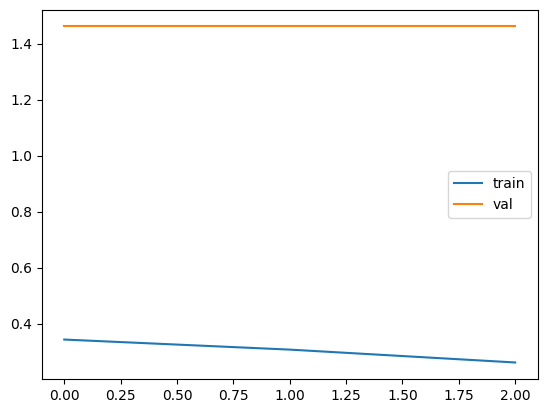

```python
# Select the best fold (i.e. first fold)
best_fold_idx_new = 2

# Get predicted logits and true labels from the best fold
preds_best_fold_new = all_preds_new[best_fold_idx_new]  # Predicted logits
labels_best_fold_new = all_labels_new[best_fold_idx_new]  # True labels


# Convert logits to class predictions
pred_labels_best_fold_new = np.argmax(preds_best_fold_new, axis=1)

# Compute accuracy
accuracy_best_fold_new = accuracy_score(labels_best_fold_new, pred_labels_best_fold_new)

print(f"Accuracy for Best Fold {best_fold_idx_new + 1}: {accuracy_best_fold_new:.4f}")

# take the loss values from the best performing fold
history_scv_new['val_loss_new'] = history_scv_new['val_loss_new'][6:9]
history_scv_new['train_loss_new'] = history_scv_new['train_loss_new'][6:9]

# Plot the loss values
plt.plot(history_scv_new['train_loss_new'], label='train')
plt.plot(history_scv_new['val_loss_new'], label='val')
plt.legend()
plt.show()
```

As observed in previous base model, this new model also does not require more than 1 epoch as there is no improvement in validation loss after that. The accuracy is 35% which is lower than the base model that had 79% accuracy. This indicates that the BERT model performs better if changes (as per new model) are not made.

# Fine tuning within base model

This we will unfreeze last two layers, pooling layer, classifier layer, and add custom layers.

```python
# Load the new model
model_new_1 = BertForSequenceClassification.from_pretrained(model_base_path)
```

```python
# place the new model to GPU
model_new_1.to(device)
```

```
BertForSequenceClassification(
  (bert): BertModel(
    (embeddings): BertEmbeddings(
      (word_embeddings): Embedding(30522, 768, padding_idx=0)
      (position_embeddings): Embedding(512, 768)
      (token_type_embeddings): Embedding(2, 768)
      (LayerNorm): LayerNorm((768,), eps=1e-12, elementwise_affine=True)
      (dropout): Dropout(p=0.1, inplace=False)
    )
    (encoder): BertEncoder(
      (layer): ModuleList(
        (0-11): 12 x BertLayer(
          (attention): BertAttention(
            (self): BertSdpaSelfAttention(
              (query): Linear(in_features=768, out_features=768, bias=True)
              (key): Linear(in_features=768, out_features=768, bias=True)
              (value): Linear(in_features=768, out_features=768, bias=True)
              (dropout): Dropout(p=0.1, inplace=False)
            )
            (output): BertSelfOutput(
              (dense): Linear(in_features=768, out_features=768, bias=True)
              (LayerNorm): LayerNorm((768,), eps=1e-12, elementwise_affine=True)
              (dropout): Dropout(p=0.1, inplace=False)
            )
          )
          (intermediate): BertIntermediate(
            (dense): Linear(in_features=768, out_features=3072, bias=True)
            (intermediate_act_fn): GELUActivation()
          )
          (output): BertOutput(
            (dense): Linear(in_features=3072, out_features=768, bias=True)
            (LayerNorm): LayerNorm((768,), eps=1e-12, elementwise_affine=True)
            (dropout): Dropout(p=0.1, inplace=False)
          )
        )
      )
    )
    (pooler): BertPooler(
      (dense): Linear(in_features=768, out_features=768, bias=True)
      (activation): Tanh()
    )
  )
  (dropout): Dropout(p=0.1, inplace=False)
  (classifier): Linear(in_features=768, out_features=3, bias=True)
)
```

```python
# Freeze the entire model initially
for param in model_new_1.parameters():
    param.requires_grad = False

# Unfreeze the last 2 layers of BERT
for layer in model_new_1.bert.encoder.layer[-2:]:
    for param in layer.parameters():
        param.requires_grad = True

# Also unfreeze the pooler (final layer before classifier)
for param in model_new_1.bert.pooler.parameters():
    param.requires_grad = True

# Unfreeze the classifier layer, as we want to modify or retrain it for our new task
for param in model_new_1.classifier.parameters():
    param.requires_grad = True

# Add custom layers to the model
model_new_1.dropout = nn.Dropout(0.5).to(device)  # Dropout layer
model_new_1.dense = nn.Linear(model_new_1.config.hidden_size, model_new_1.config.hidden_size).to(device)   # Reduce to 256 to control model complexity
model_new_1.relu = nn.ReLU().to(device)  # ReLU activation
model_new_1.classifier = nn.Linear(model_new_1.config.hidden_size, 3).to(device)   # Final classification layer for 3 classes

# Similar to before collect trainable parameters: last 2 BERT layers, pooler layer, classifier, and custom layers
train_params_new_1 = (
    list(model_new_1.bert.encoder.layer[-2:].parameters()) +  # Last 2 BERT layers
    list(model_new_1.bert.pooler.parameters()) +  # Pooler layer
    list(model_new_1.dropout.parameters()) +  # Dropout layer
    list(model_new_1.dense.parameters()) +  # Custom dense layer
    list(model_new_1.relu.parameters()) +  # ReLU (if needed, but it's usually stateless)
    list(model_new_1.classifier.parameters())  # Final classifier layer
)

# we can now tell the optimizer to only optimize these parameters in the model
optimizer_new_1 = Adam(train_params_new_1)
```

## Train new model

Let's train our new model and evaluate its performance. All the parameters like number of splits for stratified CV, batch size, and number of epochs will remain same.

```python
# Need to run this again to udpate these tensors before training the new fine-tuned model

# Extract input tensors and labels from dataset
input_ids = torch.stack([sample['input_ids'].squeeze(0) for sample in encoded_dataset], dim=0)
attention_mask = torch.stack([sample['attention_mask'].squeeze(0) for sample in encoded_dataset], dim=0)
token_type_ids = torch.stack([sample['token_type_ids'] for sample in encoded_dataset], dim=0)
label_ids = torch.tensor([sample['label_id'] for sample in encoded_dataset], dtype=torch.long)

# Convert labels to NumPy array for StratifiedKFold (use CPU)
labels_np = label_ids.cpu().numpy()

# Create the full dataset
all_data_tensors = TensorDataset(input_ids, attention_mask, token_type_ids, label_ids)
```

```python
# Store training times
New_fine_tuned_train_time = []

# track the training and validation losses
history_scv_new_1 = {'train_loss_new_1': [], 'val_loss_new_1': []}

# Perform Stratified K-Fold Cross-Validation
for fold, (train_idx, eval_idx) in enumerate(scv.split(input_ids, labels_np)):

    print(f"\n--- Fold {fold + 1}/{n_splits} ---")

    # Subset dataset using train and eval indices
    train_data = Subset(all_data_tensors, train_idx)
    eval_data = Subset(all_data_tensors, eval_idx)

    # Create DataLoaders
    train_dataloader = DataLoader(train_data, sampler=RandomSampler(train_data), batch_size=Batch_size)
    eval_dataloader = DataLoader(eval_data, sampler=SequentialSampler(eval_data), batch_size=Batch_size)

    # Reinitialize the new model for each fold
    model_new_1.to(device)

    # Start timing
    start_time = time.time()

    with trange(epochs, desc=f"Epoch (Fold {fold + 1})") as pbar:
        for epoch in pbar:
            model_new_1.train()
            total_loss_new_1 = 0.0

            # iterate over training data in batchs using train_dataloader.
            for batch in tqdm(train_dataloader, desc=f"Training {epoch}", total=len(train_dataloader), leave=False):

                batch = tuple(s.to(device) for s in batch)
                input_ids, input_mask, input_types, labels = batch

                output = model_new_1(input_ids=input_ids, attention_mask=input_mask, labels=labels)

                # Backpropagation
                output.loss.backward()
                optimizer.step()
                optimizer.zero_grad()

                total_loss_new_1 += output.loss.item() * Batch_size

            total_loss_new_1 = total_loss_new_1 / len(train_dataloader.dataset)
            history_scv_new_1['train_loss_new_1'].append(total_loss_new_1)
            pbar.set_postfix(loss=f"{total_loss_new_1:.2f}")

            # Evaluation
            model_new_1.eval()
            total_loss_new_1 = 0.0

            with torch.no_grad():
                for batch in tqdm(eval_dataloader, desc=f"Evaluating {epoch}", total=len(eval_dataloader), leave=False):
                    batch = tuple(s.to(device) for s in batch)
                    input_ids, input_mask, input_types, labels = batch

                    output = model_new_1(input_ids, input_types, input_mask, labels=labels)
                    total_loss_new_1 += output.loss.item() * Batch_size

            total_loss_new_1 = total_loss_new_1 / len(eval_dataloader.dataset)
            history_scv_new_1['val_loss_new_1'].append(total_loss_new_1)
            pbar.set_postfix(val_loss=f"{total_loss_new_1:.2f}")

    # End timing
    end_time = time.time()
    fold_time_finetuned = end_time - start_time
    New_fine_tuned_train_time.append(fold_time_finetuned)
    print(f"Training time for Fold {fold + 1}: {fold_time_finetuned:.2f} seconds")

print("\nCross-validation complete!")
print("New fine-tuned model training time (seconds):", New_fine_tuned_train_time)
```

```
--- Fold 1/3 ---
```

```
Training time for Fold 1: 386.16 seconds

--- Fold 2/3 ---
```

```
Training time for Fold 2: 386.29 seconds

--- Fold 3/3 ---
```

```
Training time for Fold 3: 386.27 seconds

Cross-validation complete!
New fine-tuned model training time (seconds): [386.1643421649933, 386.28585171699524, 386.2680027484894]
```

```python
New_fine_tuned_train_time
```

```
[386.1643421649933, 386.28585171699524, 386.2680027484894]
```

## Save the fine-tuned model

```python
# Define save directory (for Jupyter notebook only)
save_directory_new_1= "bert_model_new_1"

# Save the model
model_new_1.save_pretrained(save_directory_new_1)

# Save the tokenizer
tokenizer.save_pretrained(save_directory_new_1)

print(f"New fine tuned Model and tokenizer saved to: {save_directory_new_1}")
```

```
New fine tuned Model and tokenizer saved to: bert_model_new_1
```

## New fine-tuned model's predictions and accuracy

```python
all_preds_new_1 = []   # Stores predicted labels for each fold
all_labels_new_1 = []  # Stores true labels for each fold

# Extract labels for stratification because it requires labels for equal proportion of classes cross folds
labels_array = np.array([tensor[-1].cpu().numpy() for tensor in all_data_tensors]) # Assuming last tensor is labels

# Cross-validation loop
for fold, (train_idx, eval_idx) in enumerate(scv.split(np.zeros(len(labels_array)), labels_array)):

    print(f"Evaluating fold {fold + 1}/{n_splits}...")

    model_new_1.eval()  # Set model to evaluation mode

    # Create evaluation dataset and dataloader for this fold
    eval_data_scv = torch.utils.data.Subset(all_data_tensors, eval_idx)
    eval_sampler_scv = SequentialSampler(eval_data_scv)
    eval_dataloader_scv = DataLoader(eval_data_scv, sampler=eval_sampler_scv, batch_size=Batch_size)

    fold_preds_new_1 = []  # Store predictions for this fold
    fold_labels_new_1 = []  # Store true labels for this fold

    # Run evaluation without tracking gradients
    with torch.no_grad():
        for batch in tqdm(eval_dataloader_scv, desc=f"Evaluating Fold {fold + 1}", total=int(len(eval_data_scv)/Batch_size)+1):

            batch = tuple(s.to(device) for s in batch)  # Move batch to GPU/CPU
            input_ids, input_mask, input_types, labels = batch

            # Forward pass (ensure correct argument names)
            output = model_new_1(input_ids=input_ids, attention_mask=input_mask, labels=None)

            # Store predictions and labels
            fold_preds_new_1.append(output.logits.detach().cpu().numpy())
            fold_labels_new_1.append(labels.cpu().numpy())

    # Store predictions per fold
    all_preds_new_1.append(np.concatenate(fold_preds_new_1, axis=0))  # Convert list of batches to array
    all_labels_new_1.append(np.concatenate(fold_labels_new_1, axis=0))  # Convert list of labels to array
```

```
Evaluating fold 1/3...
```

```
Evaluating fold 2/3...
```

```
Evaluating fold 3/3...
```

```python
print(history_scv_new_1)
```

```
{'train_loss_new_1': [1.124261732936432, 1.11883011667039, 1.1300043433303284, 1.1165623504217128, 1.1275938654643813, 1.123231012026056, 1.1245725445570647, 1.1267417757247697, 1.1231908878323773], 'val_loss_new_1': [1.0679674171682951, 1.0679674171682951, 1.0679674171682951, 1.0679803180331213, 1.…
```

Looking at the validation loss values between epochs for each fold, we can say that the model has same performance for each fold. Same is true for training loss. So we will just pick first fold. The running time was 386.16 seconds for this fold. Now comparing the validation loss values between this model and previous model, we can see that the loss improved slightly since the loss was 1.46 for prevoius model. But this model has worse training accuracy since the loss is 1.12 while it was 0.34.

```
Accuracy for Best Fold 1: 0.3292
```

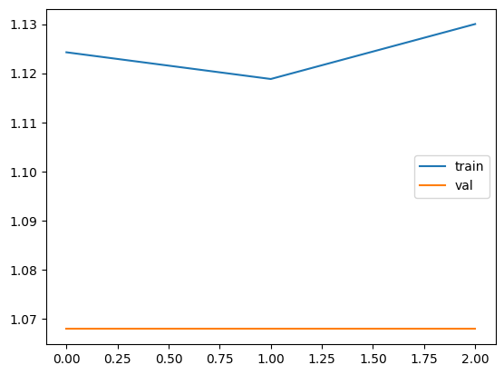

```python
# Select the best fold (i.e. first fold)
best_fold_idx_new_1 = 0

# Get predicted logits and true labels from the best fold
preds_best_fold_new_1 = all_preds_new_1[best_fold_idx_new_1]  # Predicted logits
labels_best_fold_new_1 = all_labels_new_1[best_fold_idx_new_1]  # True labels


# Convert logits to class predictions
pred_labels_best_fold_new_1 = np.argmax(preds_best_fold_new_1, axis=1)

# Compute accuracy
accuracy_best_fold_new_1 = accuracy_score(labels_best_fold_new_1, pred_labels_best_fold_new_1)

print(f"Accuracy for Best Fold {best_fold_idx_new_1 + 1}: {accuracy_best_fold_new_1:.4f}")

# take the loss values from the best performing fold
history_scv_new_1['val_loss_new_1'] = history_scv_new_1['val_loss_new_1'][:3]
history_scv_new_1['train_loss_new_1'] = history_scv_new_1['train_loss_new_1'][:3]

# Plot the loss values
plt.plot(history_scv_new_1['train_loss_new_1'], label='train')
plt.plot(history_scv_new_1['val_loss_new_1'], label='val')
plt.legend()
plt.show()
```

The accuracy score decreases slightly from 35% to 32% indicating that the fine tuning of the layers and adding custom layers on top of BERT model negatively impacted the model's performance.

# Comparison

```python
history_base['train_loss'] = [0.6308016816888566, 0.5666386944045749, 0.5653283992061019]
history_base['val_loss'] = [1.7058421509217176, 2.1750976141654457, 2.533772724906094]

history_scv_new['train_loss_new'] = [0.3427173152829191, 0.30677744188253386, 0.2607930279651397]
history_scv_new['val_loss_new'] = [1.4614578906531228, 1.4614578906531228, 1.4614578906531228]

history_scv_new_1['train_loss_new_1'] = [1.124261732936432, 1.11883011667039, 1.1300043433303284]
history_scv_new_1['val_loss_new_1'] = [1.0679674171682951, 1.0679674171682951, 1.0679674171682951]
```

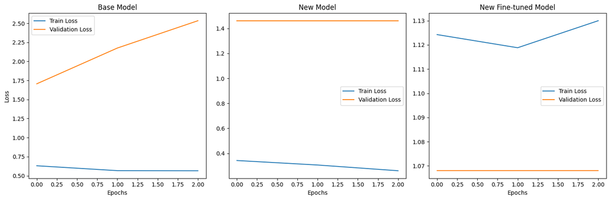

[output not shown]

```python
# Create a figure with 3 subplots (1 row, 3 columns)
fig, axes = plt.subplots(1, 3, figsize=(15, 5))

# Plot the first loss curves
axes[0].plot(history_base['train_loss'], label='Train Loss')
axes[0].plot(history_base['val_loss'], label='Validation Loss')
axes[0].set_title('Base Model')
axes[0].set_xlabel('Epochs')
axes[0].set_ylabel('Loss')
axes[0].legend()

# Plot the second loss curves
axes[1].plot(history_scv_new['train_loss_new'], label='Train Loss')
axes[1].plot(history_scv_new['val_loss_new'], label='Validation Loss')
axes[1].set_title('New Model')
axes[1].set_xlabel('Epochs')
axes[1].legend()

# Plot the third loss curves
axes[2].plot(history_scv_new_1['train_loss_new_1'], label='Train Loss')
axes[2].plot(history_scv_new_1['val_loss_new_1'], label='Validation Loss')
axes[2].set_title('New Fine-tuned Model')
axes[2].set_xlabel('Epochs')
axes[2].legend()

# Adjust layout for better spacing
plt.tight_layout()
plt.show()


print(f"Best accuracy for base model {accuracy_best_fold}, and running time was {Base_model_running_time[0]}")
print(f"Best accuracy for new model {accuracy_best_fold_new}, and running time was {New_model_running_time[2]}")
print(f"Best accuracy for new fine-tuned model {accuracy_best_fold_new}, and running time was {New_fine_tuned_train_time[0]}")
```

As stated in previous observations, the accuracy was the highest for the base model where no custom layers were added. As we start to adjust the layers to be used for classification and add custom layers on top of the base model, the accuracy score starts to decrease. Comparing the best performing folds for all three models, the new model without further fine tuning took the short time for running.

```python
!jupyter nbconvert --to html Lab_Transfer_Learning_and_Transformers.ipynb
```

```
[NbConvertApp] Converting notebook Lab_Transfer_Learning_and_Transformers.ipynb to html
[NbConvertApp] Writing 1001171 bytes to Lab_Transfer_Learning_and_Transformers.html
```